# Identifying Schools with Biggest Differences in Math Test Scores, Part 2

YOUR NAME

```r
knitr::opts_chunk$set(echo = TRUE)
library(tidyverse)
options(scipen = 999)
```

### Introduction

In the class activity, you tested a school board member’s claim using data from Montgomery County, Pa. — and found a model that didn’t hold up. Now you’ll run the same analysis using data from Montgomery County, Md. Your job is to evaluate whether the Maryland data tells a different story, and what that means for how you’d report on the claim.

### Loading the Data

```r
schools <- read_csv("https://raw.githubusercontent.com/dwillis/jour405_files/refs/heads/main/montgomery_md.csv")
```

### Task 1: Examine the Data First (2 points)

Before you plot anything, look at the data — you know why by now.

```r
summary(schools$`FARMS Pct`)
```

```
##    Min. 1st Qu.  Median    Mean 3rd Qu.    Max.
##    4.00   15.10   32.50   39.07   62.30   96.00
```

```r
schools |> arrange(desc(`FARMS Pct`)) |> head(10)
```

```
## # A tibble: 10 × 4
##    `School Name`              `School Type` `FARMS Pct` % Met or Exceeded Math…¹
##    <chr>                      <chr>               <dbl>                    <dbl>
##  1 Broad Acres Elementary     Elementary           96                       39.4
##  2 Harmony Hills Elementary   Elementary           89.3                     15.7
##  3 South Lake Elementary      Elementary           85.8                     19.8
##  4 Gaithersburg Elementary    Elementary           85.1                     14.9
##  5 Wheaton Woods Elementary   Elementary           84.3                     38.4
##  6 Kemp Mill Elementary       Elementary           83.3                     12.3
##  7 Summit Hall Elementary     Elementary           82.9                     24
##  8 Sargent Shriver Elementary Elementary           82.1                     14.3
##  9 Georgian Forest Elementary Elementary           80.4                     24.5
## 10 Highland Elementary        Elementary           79.5                     44.3
## # ℹ abbreviated name: ¹`% Met or Exceeded Math Expectations`
```

Are there any data quality issues like the ones you found in the Pennsylvania data? How does the distribution of FARMS percentages compare between the two counties? Note anything that concerns you or gives you confidence in the data.

This data set looks way better than the Pennsylvania one because there are no impossible values (eg: 100% / 0%); the data has a wide realistic range and there are no data clusters as such, like there was with the schools at 100% in the first data set. The only concerning thing is that there are a lot of schools at 4% FARMS which could indicate a data floor.

### Task 2: Create a Scatterplot and Compare (5 points)

Replace the REPLACE_ME value with the correct variable name to create a scatterplot of FARMS percentage vs. math scores for Montgomery County, Md.

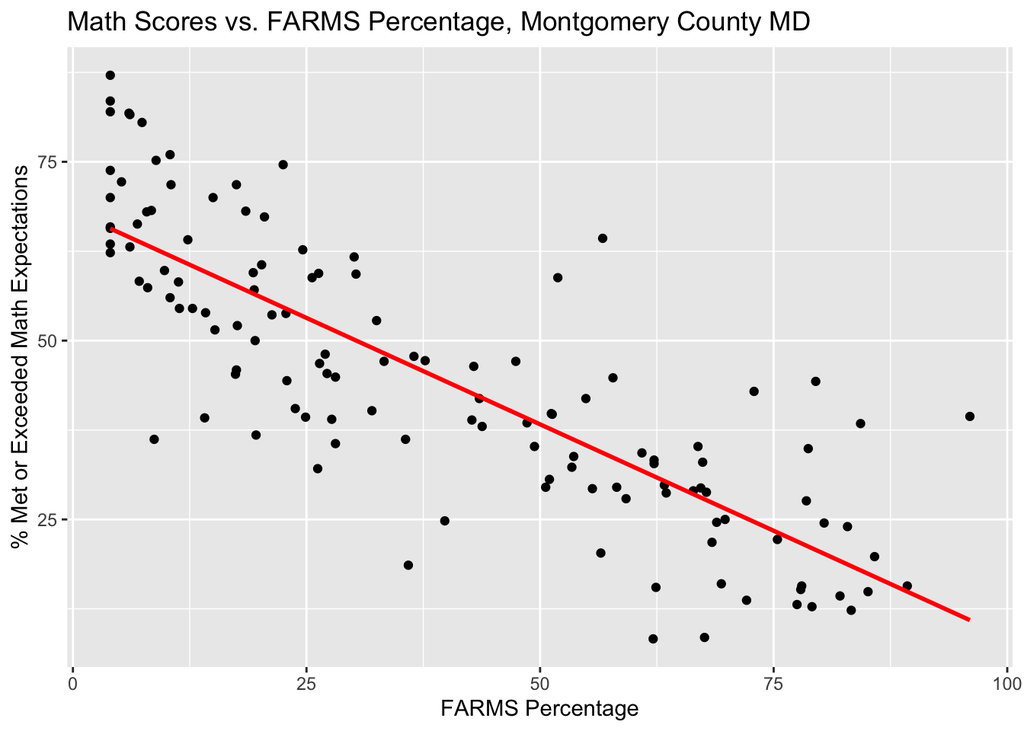

```r
schools |>
  ggplot(aes(x = `FARMS Pct`, y = `% Met or Exceeded Math Expectations`)) +
  geom_point() +
  geom_smooth(method = "lm", se = FALSE, color = "red") +
  labs(x = "FARMS Percentage", y = "% Met or Exceeded Math Expectations",
       title = "Math Scores vs. FARMS Percentage, Montgomery County MD")
```

Describe what you see. Then compare this scatterplot specifically to the Pennsylvania one: what differences do you notice in the direction, strength, and spread of the relationship? The two counties share a name and are both suburban — what might explain why they look so different?

The relationship is clearly negative as FARMS percentage increase, math scores tend to decrease. Schools with low rates have high scores and vice versa. The line slops downward and the points cluster pretty tightly around it.

In comparison to Pennsylvania this is much clearer and more consistent. The strength of the correlation appears a lot stronger, where as the Penn one was weaker.

They look so different because there might be a difference in the data quality and the high standard of collection. Montgomery county is larger and more diverse district also, which means the data will likely produce stronger patterns between economic disparity and performance.

### Task 3: Linear Regression Model (5 points)

Replace the REPLACE_ME value with the correct variable name to run a linear regression model predicting math scores from FARMS percentage.

```r
model <- lm(`% Met or Exceeded Math Expectations` ~ `FARMS Pct`, data = schools)
summary(model)
```

```
##
## Call:
## lm(formula = `% Met or Exceeded Math Expectations` ~ `FARMS Pct`,
##     data = schools)
##
## Residuals:
##      Min       1Q   Median       3Q      Max
## -28.0844  -6.0538  -0.6803   6.1267  29.9939
##
## Coefficients:
##             Estimate Std. Error t value            Pr(>|t|)
## (Intercept) 68.04878    1.74143   39.08 <0.0000000000000002 ***
## `FARMS Pct` -0.59511    0.03685  -16.15 <0.0000000000000002 ***
## ---
## Signif. codes:  0 '***' 0.001 '**' 0.01 '*' 0.05 '.' 0.1 ' ' 1
##
## Residual standard error: 11.04 on 125 degrees of freedom
## Multiple R-squared:  0.676,  Adjusted R-squared:  0.6734
## F-statistic: 260.8 on 1 and 125 DF,  p-value: < 0.00000000000000022
```

Report the three key statistics: the p-value, the Adjusted R-squared, and the coefficient for FARMS Pct. Then interpret them together — not separately. What does the combination of these three numbers tell you about the relationship between poverty and math scores in Montgomery County, Md.? Is this model worth using? How does it compare to the Pennsylvania model?

Coefficient: -0.595 p-value: < 0.00000000000000022 (basically 0) Adj R-squared: 0.6734

Altogether these results show a strong, significant negative relationship between poverty and math grades in Montgomery County. The coefficient means that for every 1 % point increase in FARMS, the percent of students meeting math expectations drops by about 0.6 points, which adds into a large impact across schools with differing poverty/economic levels. The p-value is very small and confirms the relationship is not due to chance.The Adj R-squared shows the model explains about 67% of the variation in scores, making it both meaningful.

Overall, this data set and its results are much stronger than the PA set- the MD data provides convincing evidence that higher poverty is linked to lower math performance.

### Task 4: Identifying Schools with the Biggest Residuals (6 points)

Replace the REPLACE_ME values with the correct variable names to calculate predicted values, residuals, and absolute residuals for each school. Then arrange the schools in descending order of absolute residuals.

```r
schools <- schools |>
  mutate(
    predicted = predict(model),
    residual = `% Met or Exceeded Math Expectations` - predicted,
    abs_residual = abs(residual)
  ) |>
  arrange(desc(abs_residual))

head(schools |> select(1, `FARMS Pct`, `% Met or Exceeded Math Expectations`, predicted, residual), 10)
```

```
## # A tibble: 10 × 5
##    `School Name`           `FARMS Pct` % Met or Exceeded Ma…¹ predicted residual
##    <chr>                         <dbl>                  <dbl>     <dbl>    <dbl>
##  1 Fox Chapel Elementary          56.7                   64.3      34.3     30.0
##  2 Broad Acres Elementary         96                     39.4      10.9     28.5
##  3 Germantown Elementary          35.9                   18.6      46.7    -28.1
##  4 Somerset Elementary             8.7                   36.2      62.9    -26.7
##  5 Highland Elementary            79.5                   44.3      20.7     23.6
##  6 Stedwick Elementary            62.1                    8.3      31.1    -22.8
##  7 Dr. Charles R. Drew El…        51.9                   58.8      37.2     21.6
##  8 Carderock Springs Elem…         4                     87.1      65.7     21.4
##  9 Wheaton Woods Elementa…        84.3                   38.4      17.9     20.5
## 10 Sligo Creek Elementary         14.1                   39.2      59.7    -20.5
## # ℹ abbreviated name: ¹`% Met or Exceeded Math Expectations`
```

Identify the school with the largest positive residual (doing much better than the model predicts) and the school with the largest negative residual (doing much worse). For each school, find its zip code and look it up on [CensusReporter.org](https://censusreporter.org).

For each of the two schools, answer: - What does the demographic and economic profile of the zip code look like? - Does anything in that profile help explain why the school is over- or under-performing the model? - What would your first reporting question be to the principal of that school?

Largest +ve residual: Fox Chapel Elementary Very diverse population with Black, White, Hispanic, and Asian categories all having 19%-24% of the population each. The median income is 20% higher than that of the MD average. Only 8.9% of people are below the poverty line, slightly lower than the overall MD rate with 14% of children below this line. Even though the school has a relatively high FARMS rate, the broader community appears stable and diverse which can in turn provide more resources and stability. This suggests the model may be missing context, like family income or school-level programs that help students succeed despite higher poverty levels . Reporting Q: “Your school is significantly outperforming expectations given its FARMS rate. What programs and/or teaching strategies do you think are driving you toward that success?”

Largest -ve residual: Germantown Elementary The median age is 5 years younger than the other school’s age. There is a bigger Hispanic community, making up 28% of the population, with White at 25%, Black at 19% and Asian at 16%. The median income is $143,800 a year, 1.4x the MD avg. There is no data for poverty levels. Despite high median income, the school is performing far below expectations, menaing income alone doesn’t tell the full story. Factors might include language barriers and uneven access to resources= shows that schools in similar areas can have very different outcomes. Reporting Q: “Given the relatively strong economic standing of your community, what challenges do you think are contributing to subpar math scores at your school?”

### Task 5: Evaluate the Model and Write the Pitch (7 points)

You’ve now run this analysis on two counties. Return to the school board member’s claim: that elementary schools with fewer students on free and reduced-price meals do better on standardized math tests.

Write a short story pitch of 4-6 sentences that addresses all of the following: Does the Maryland data support or contradict the claim? How does it compare to what you found in Pennsylvania? What would you ask the school board member if you called them for comment? And what’s the most interesting specific finding from your residuals analysis: which school would you want to visit first, and why?

The MD data supports the school board’s claim: there is a clear and statistically significant relationship between lower poverty rates and higher math performance, unlike the weaker pattern in PA. Comparison between the two shows that this relationship is not universal and depends heavily on local contexts.

If I called the school board member, I would ask whether they are relying on data from districts like Montgomery County where the relationship is strong, and how they explain places where it breaks down.

The most interesting finding comes from further analysis: Fox Chapel Elementary outperforms expectations, while Germantown Elementary under performs despite being in an economically strong area. I would want to visit Fox Chapel first to understand what is working there and whether those strategies could be replicated in struggling schools.